# Homework of all time

22081

2022-12-11

## Homework of the semester

There are 11 times in total

## 1st

## Question

*Use knitr to produce at least three examples* (texts,figures,tables).

## Answer

**1.text part**

```r
s = "This is THE Euler's Formular"
print(s)
```

```
## [1] "This is THE Euler's Formular"
```

${\rm e}^{i\theta} = cos\theta + isin\theta$

**2.figure part**

**objective** *construct a color disk with a pie chart*

First we adjust some marginal distances.

Then we use function “pie” to finish the job with 1000 colors chosen by function “rainbow”.

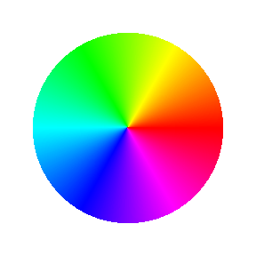

```r
par(mar = rep(0,4))
cols <- rainbow(1000) #pick colors from rainbow the function
pie(rep(1,1000),labels = NA,col = cols,border = cols)
```

## 2nd

## Question

Exercise **3.3**, **3.7**, **3.12** and **3.13**(pages 94-96,Statistical Computating with R)

## Answer

**(1) 3.3**

**First** Use the inverse transform method to simulate a random sample from the Pareto(2, 2) distribution  
**Then** Superimpose the Pareto(2, 2) density function itself on the histogram generated by those random numbers.

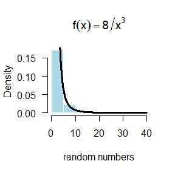

```r
n <- 1000
set.seed(777)  #set a seed
u <- runif(n)
x <- 2/sqrt(1-u) #generate the random numbers
hist(x,
     freq = F,
     main =expression(f(x) == 8 / x ^ 3),
     xlim = c(0 , 40),
     col = "Light Blue",
     border = "White",
     xlab = "random numbers",
     las = 1)
check<- seq(0 , 40 , .01)
lines( check ,
       8 / (check ^ 3),
       lwd = 3)
```

**Conclusion** From the figure we can see that the empirical and theoretical distributions approximately agree.

**(2) 3.7**

**First** Write a function as the question instructed to generate a random sample

**Then** Generate a sample using the parameters given below

**And last but not least** Graph the empirical histogram with a theoretical density superimposed.

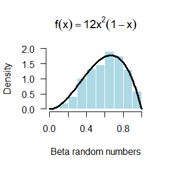

```r
set.seed(329)  #set a seed
betafun <- function(n, alpha, beta)
{
a <- alpha
b <- beta
lim <-  n     #acquire all the parameters from the function
k <- 0
y <- numeric(lim)
while(k < lim){
    x <- runif(1)
    if( x^(a - 1) * (1 - x)^(b - 1)> runif(1))
    {
        k <- k + 1
        y[k] <- x
      }
} #generate random numbers via acceptance-rejection method
   return(y)
}#construct a function which makes a given numbers of random sample from Beta(a, b)
brdm = betafun(1000, 3, 2) #use the function to produce 1000 random numbers
hist(brdm,
     freq = F,
     main = expression(f(x) == 12 * x^2 *(1 - x)),
     ylim = c(0 , 2),
     col = "Light Blue",
     border = "White",
     las = 1,
     xlab = "Beta random numbers"
     )
check <- seq(0, 1, .01 )
lines(check,
      12 * check ^ 2 * (1 - check),
      lwd = 3)
```

**Conclusion** From the figure we can see that the empirical and theoretical distributions approximately agree again.

**(3) 3.12**

Obtain a random sample required of the *Exponential-Gamma* mixture and gain a histogram of it

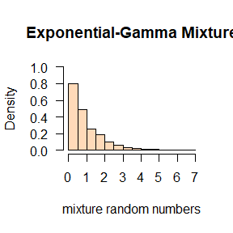

```r
set.seed(777) #set a seed
n <- 1000
r <- 4
beta <- 2
lambda <- rgamma(n, r, beta)
rdm <- rexp(lambda)
hist(rdm,
     freq = F,
     main = "Exponential-Gamma Mixture",
     ylim = c(0, 1),
     col = "Peachpuff",
     border = "Black",
     xlab = "mixture random numbers",
     las = 1)
```

**(4) 3.13**

**First** we generate that mixture function sample and graph a histogram of it.

**Then** we add the density curve over this figure

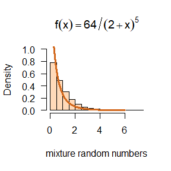

```r
set.seed(888)  #set a seed
n <- 1000
r <- 4
beta <- 2
lambda <- rgamma(n, r, beta)
rdm <- rexp(lambda)
hist(rdm,
     freq = F,
     main = expression(f(x) == 64 / (2 + x) ^ 5),
     ylim = c(0, 1),
     col = "Peachpuff",
     border = "Black",
     xlab = "mixture random numbers",
     las = 1)
lines(check <-  seq(0, 6, .01),
      64 / (2 + check) ^ 5,
      lwd = 3,
      col = "Chocolate")
```

**Conclusion** From the figure we can see that the empirical and theoretical distributions approximately agree yet again.

## 3rd

## Question:

• For $n = 10^{4}, 2 × 10^{4}, 4 × 10^{4}, 6 × 10^{4}, 8 × 10^{4}$, apply the fast sorting algorithm to randomly permuted numbers of 1, . . . , n.

• Calculate computation time averaged over 100 simulations, denoted by $a_{n}$.

• Regress $a_{n}$ on $t_{n}$ := n log(n), and graphically show the results (scatter plot and regression line).

## Answer:

*step1*

first we construct a quicksorting function which could not only perform a quicksorting but count the time complexity during the process

```r
quick_sort<-function(sample){
  num<-length(sample)                          #acquire the sample for sorting
  if(num==0||num==1){return(sample)
  }else{
    first_one<-sample[1]                       #pick a number
    rest_ones<-sample[-1]
    lower<-rest_ones[rest_ones < first_one]
    upper<-rest_ones[rest_ones >= first_one]   #sort the sample according to the quicksorting algorithm
    count <<-  count + num - 1                 #jot down the number of times of comparison i.e. time complexity
    return(c(quick_sort(lower),first_one,quick_sort(upper)))} #recursion until the sample is completely sorted
}
```

*step2*

use a double for-loops to permute as well as compute the time complexity of 5 given quantity of numbers for 100 times each. So to speak we use the first for loop to assign a certain quantity of a sample, then we use the latter one to permute 100 times for that sample Finally these loops return an array whose elements are the average time complexity of the 5 quantity of numbers,i.e. $n=10^{4}, 2×10^{4}, 4×10^{4}, 6×10^{4}, 8×10^{4}$

```r
a <- numeric(5)                              #array "a" to contain the five results
total <- c(1e4, 2e4, 4e4, 6e4, 8e4)
for (j in 1:5) {
    total_count <- numeric(100)
    #the array "total_count" is to contain the time complexity created by the following loop
    for (i in 1:100) {
        count <- 0
        random_sample <- sample(1:total[j])
        quick_sort(random_sample)
        total_count[i] <- count
    }
    a[j]<- sum(total_count) / 100
}
knitr::kable(a,
             "pipe",
             col.names = "average time complexity",
             align = "l") #print array "a"
```

| average time complexity |
| --- |
| 155976.5 |
| 340085.0 |
| 734000.5 |
| 1152066.5 |
| 1578794.2 |

*step3*

regress $a_{n}$ and draw $t_{n}$=nlog(n) superimpose on it

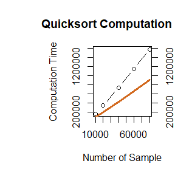

```r
par(mar = c(5, 8, 4, 2),
    yaxt = "s")
plot(total,
     a,
     main = "Quicksort Computation Time",
     type = "b",
     xlab = "Number of Sample",
     ylab = "Computation Time",
     )                #regress array "a"
axis(side = 4)
line <- seq(1, 80000, 1)
lines(line, line*log(line),
      lwd = 3,
      col = "Chocolate") #draw nlog(n)
```

**conclusion** from the graphic we can find that the time complexity is O(nlog(n))

## Question:

consider antithetic approach on $\hat{\theta} = \int_{0}^{1} e^x\; dx$ ,Compute **Cov($e^{U}$, $e^{1-U}$)** and **Var($e^{U}$ + $e^{1-U}$)** , where $U \sim$Uniform(0, 1),compare variance of $\hat{\theta}$ estimated with antithetic variate with that of simple MC.

## Answer:

$$\begin{align*}
&Cov(e^{U}, e^{1-U}) = E(e^{U} - (e - 1))(e^{1-U} - (e -
1))=e-(e-1)^{2}=3e-e^{2}-1\\
&whereE(e^{U}) = E(e^{1-U}) = \int_{0}^{1} e^u\; du = e - 1\\
&Var(e^{u})=E(e^{u}-(e-1))^{2}=Ee^{2u}-(e-1)^{2}=\frac{1}{2}e^{2}-\frac{1}{2}-e^{2}+2e-1=2e-\frac{1}{2}e^{2}-\frac{3}{2}\\
&where E(e^{2u})=\int_{0}^{1} e^{2u}\;
du=\frac{1}{2}e^{2}-\frac{1}{2}\\
&Var(e^{u}+e^{1-u})=2Var(e^{u}) +
2Cov(e^{u},e^{1-u})=4e-e^{2}-3+6e-2e^{2}-2=10e-3e^{2}-5\\
&hence \frac{\hat{\theta}_{antithetic}}{\hat{\theta}_{simple}} =
\frac{\frac{1}{2}×Var(e^{u}+e^{1-u})}{Var(e^{u})}\approx0.03232\\
\end{align*}$$

so the percent reduction being $1-0.03232=0.96768$

## Question:

Use a Monte Carlo simulation to estimate θ by the antithetic variate approach and by the simple Monte Carlo method. Compute an empirical estimate of the percent reduction in variance using the antithetic variate. Compare the result with the theoretical value

## Answer:

*step1*

first construct a function of simple method or using antithetic variate to achieve Monte Carlo simulation

```r
MC.simple_n_antithetic <- function(x, R = 1000, antithetic = FALSE){
    front_half <- runif(R/2)
    if(antithetic) back_half <- 1-front_half
    else           back_half <- runif(R/2)
    total_sample <- c(front_half, back_half)
    return(mean(x * exp(x * total_sample)))
}
```

*step2*

estimate $\theta$ by the antithetic approach and simple MOnte Carlo method using a random sample of 1000 numbers and compute the percent reduction in variance.

```r
MC_simple <-  MC_antithetic <- vector(length = 1000)
for (i in 1:1000) {
    MC_simple[i] <- MC.simple_n_antithetic(x = 1)
    MC_antithetic[i] <- MC.simple_n_antithetic(x = 1, antithetic = TRUE)
}
reduction <- 1 - var(MC_antithetic) / var(MC_simple)
knitr::kable(c(var(MC_simple), var(MC_antithetic), reduction),
             "pipe",
             col.names = "variance and reduction",
             align = "l")
```

| variance and reduction |
| --- |
| 0.0002293 |
| 0.0000078 |
| 0.9659846 |

**conclusion** we can see the empirical estimate of the reducing percentage and the theoretical one calculated in the former question approximately agree

## 4th

## Question:

Find two importance functions $f_{1}$ and $f_{2}$ that are supported on$(1 , \infty)$and are ‘close’ to $g(x) = \frac{x^{2}}{\sqrt{2\pi}}e^{-\frac{x^{2}}{2}},\quad x>1.$ Which of your two importance functions should produce the smaller variance in estimating $\int_{1}^{\infty} \frac{x^{2}}{\sqrt{2\pi}}e^{-\frac{x^{2}}{2}} \; dx$ by importance sampling?Explian.

## Answer:

*step1*

In order to find the requested functions which are close to g(x),we could construct functions derived from $xe^{-\frac{x^{2}}{2}}\quad and \quad e^{-x}$
$$\begin{align*}
from\quad &\int_{1}^{\infty} c_{1}xe^{-\frac{x^{2}}{2}}\; dx=1\\
&c_{1}\left[\left. -e^{-\frac{x^{2}}{2}}
\right|_{1}^{\infty}\right]=1\\
&c_{1}=\sqrt{e}\\
hence\quad&f_{1}(x)=\sqrt{e}xe^{-\frac{x^{2}}{2}}=xe^{-\frac{x^{2}-1}{2}}\\
from\quad &\int_{1}^{\infty} c_{2}e^{-x}\; dx=1\\
& c_{2}\left[\left. -e^{-x} \right|_{1}^{\infty}\right]=1\\
& c_{2}= e\\
hence\quad &f_{2}(x)=e^{1 - x}
\end{align*}$$

*step2*

Here we plot the densities of f1 and f2 with g on $(1, \infty)$ to see wether they are close enough

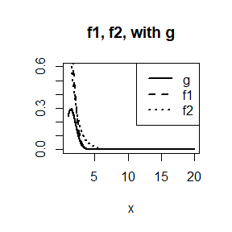

```r
x <- seq(1, 20, .01)
f1 <- sqrt(exp(1)) * x * exp(-x ^ 2 / 2)
f2 <- exp(1 - x)
g <- x ^ 2 * exp(-x ^ 2 / 2) / sqrt(2 * pi)
plot(x, g, type = "l", main = "f1, f2, with g", ylab = "", ylim = c(0, 0.6), lwd = 2)
lines(x, f1, lty = 2, lwd = 2)
lines(x, f2, lty = 3, lwd = 2)
legend("topright", legend = c("g", "f1", "f2"), lty = 1:3, lwd = 2)
```

*step3*

Here we plot the ratio g/f

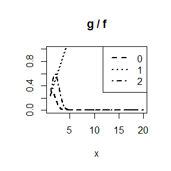

```r
plot(x, g, type = "l", main = "g / f", ylab = "", ylim = c(0, 1), lwd = 2, lty = 2)
lines(x, g / f1, lty = 3, lwd = 2)
lines(x, g / f2, lty = 4, lwd = 2)
legend("topright", legend = c(0:2), lty = 2:4, lwd = 2)
```

*step4*

Use inverse transform method to estimate the integral and the corresponding variance with step4 being f1 part

```r
m <- 1e4
set.seed(123)
theta_hat <- v <- numeric(2)
# theta_hat and v to contain estimated theta and variance of f1 and f2
g <- function(x){
    x ^ 2 * exp(-x ^ 2 / 2)/sqrt(2 * pi) * (x > 1)
}
u <- runif(m)
x <- sqrt(1 - 2 * log(1 - u))
#inverse transformation to produce random number of f1
fg <- g(x) / (sqrt(exp(1)) * x * exp(-x ^ 2 / 2))
theta_hat[1] <- mean(fg)
v[1] <- var(fg)
```

*step5*

f2 part

```r
n <- 1e4
u <- runif(n)
y <- 1 - log(1 - u)
#inverse transformation to produce random number of f2
fg <- g(y) / exp(1 - y)
theta_hat[2] <- mean(fg)
v[2] <- var(fg)
```

*step6*

print outcome of the estimate

```r
rev <- data.frame(c("f1", "f2"), est <- theta_hat, va <- v)
knitr::kable(rev, "pipe", align = "l", col.names = c("importance function", "theta hat", "variance"))
```

| importance function | theta hat | variance |
| --- | --- | --- |
| f1 | 0.3990829 | 0.0147764 |
| f2 | 0.4012403 | 0.0241642 |

**conclusion:** From the table in step 6 we could see that f1 produce the smaller variance,which is pretty reasonable considering the fact that f1 possesses a much more similar formation than f2 do.

## Question:

Obtain the stratified importance sampling estimate in Example 5.13 and compare it with the result of Example 5.10

## Answer:

*step1*

Obtain the stratified importance sampling estimate in Example 5.13

```r
M <- 1e3
u <- matrix(0, 200, 5)
# 200 * 5 matrix to store replicates of random uniform distribution numbers
x <- matrix(0, 200, 5)
# 200 * 5 matrix to store replicates of x from every strata generated by inverse transform method
fg <- matrix(0, 200, 5)
#2 200 * 5 matrix to store replicates of gi / fi from every strata
T <- numeric(5)
# T to store  theta j hat of every strata
v <- numeric(5)
# v to store sigma j square of every strata
g <- function(x){
    exp(-x - log(1 + x ^ 2)) * (x > 0) *(x < 1)
}
p <- function(j){
    -log((5 - j) / 5 +j / 5 *exp(-1))
}
# function p() to calculate endpoints of every strata
for (j in 0:4) {
    u[ ,j + 1] <- runif(M/5, p(j), p(j + 1))
    x[ ,j + 1] <- -log(exp(-p(j)) - u[ ,j + 1] * (1 - exp(-1)) / 5)
    fg[ ,j + 1] <- g(x[ ,j + 1]) / (5 * exp(-x[ ,j + 1]) / (1 - exp(-1)))
    T[j + 1] <- mean(fg[ ,j + 1])
    v[j + 1] <- var(fg[ ,j + 1])
    j <- j + 1
}
# for loop to calculate theta j hat and sigma j square of each 5 strata respectively
(theta.hat <- sum(T))
```

```
## [1] 0.5203445
```

```r
(vari <- sum(v) / (M / 5))
```

```
## [1] 2.853592e-08
```

**conclusion** From the result of 5.15 together with 5.10,we could see that both theta hat is 0.52. The estimate variance of stratified importance sampling estimate is much smaller than that of just importance function method,where the importance function approach produce a variance of 0.1 whereas the stratified importance sampling’s variance is 3e-8

## 5th

## Question

Suppose that $X_{1},...,X_{n}$ are a random sample from a from a lognormal distribution with unknown parameters. Construct a 95% confidence interval for the parameter µ. Use a Monte Carlo method to obtain an empirical estimate of the confidence level.

## Answer

*step1*

$$\begin{align*}
&\log(X_{1}),...,\log(X_{n}) \sim N(\mu,\sigma^{2})\\
&\sqrt{n}\frac{\overline{\log(X)}-\mu}{sd(\log(X))} \sim t_{n-1}\\
&so\quad the \quad 95\% \quad confidence \quad interval \quad for
\quad \mu \quad being:\\
&\left(
\overline{\log{X}}-\frac{sd(\log(X))}{\sqrt{n}}t_{n-1}(0.025)\quad,
\quad \overline{\log{X}}+\frac{sd(\log(X))}{\sqrt{n}}t_{n-1}(0.025)
\right)\\
&where\quad t_{n-1}\quad denotes\quad the\quad Student\quad t \quad
distribution \quad with \quad n-1 \quad degrees \quad of \quad freedom\\
\end{align*}$$

*step2*

**Use a Monte Carlo method to compute confidence level**

*sub step1*

Generating random numbers from lognormal distribution when $\mu = 0, \sigma^{2} = 1, i.e.X_{i} \sim LN(0, 1)$

```r
set.seed(234)
m <- 1e4
# m denotes number of simulation
n <- 10
# n denotes sample size
data_generate <- function(m, n){

lndata <- matrix(0, m, n)
  for (i in 1:m) {
    lndata[i, ] <- rlnorm(n)
  }
 return(lndata)
}
lndata <- data_generate(m, n)
# for loop to generate random sample
save(lndata,m,n, file = "4data.RData")
# save data
rm(list = ls())
gc()
```

```
##           used (Mb) gc trigger (Mb) max used (Mb)
## Ncells  624312 33.4    1366928 73.1  1366928 73.1
## Vcells 1173442  9.0    8388608 64.0  8388608 64.0
```

```r
#clear memory
```

*sub step2*

Obtain empirical confidence level when $\alpha = 0.05$

```r
alpha <- .05
load("4data.RData")
# load data
level_test <- function(m, n, lndata){
LCL <- UCL <- numeric(m)
for (i in 1:m) {
    LCL[i] <- mean(log(lndata[i, ])) - sd(log(lndata[i, ])) / sqrt(n) * qt(1 - alpha/2, df = n - 1)
    UCL[i]<- mean(log(lndata[i, ])) + sd(log(lndata[i, ])) / sqrt(n) * qt(1 - alpha/2, df = n - 1)
}
# for loop to calculate upper and lower confidence limits
outcome <- mean( (LCL <= 0) & (UCL >= 0) )
return(outcome)
}
outcome <- level_test(m, n, lndata)
# compute the mean to get the confidence level
save(outcome, file = "4outcome.RData")
# save data
rm(list = ls())
gc()
```

```
##           used (Mb) gc trigger (Mb) max used (Mb)
## Ncells  625042 33.4    1366928 73.1  1366928 73.1
## Vcells 1177078  9.0    8388608 64.0  8388608 64.0
```

```r
# clear memory
```

*sub step3*

Print result

```r
load("4outcome.RData")
report <- function(outcome){
paste(" Empirical estimate of the confidence level is:", outcome)
}
report(outcome)
```

```
## [1] " Empirical estimate of the confidence level is: 0.9495"
```

```r
write.table(outcome, file = "outcome4.txt")
rm(list = ls())
gc()
```

```
##           used (Mb) gc trigger (Mb) max used (Mb)
## Ncells  626343 33.5    1366928 73.1  1366928 73.1
## Vcells 1180635  9.1    8388608 64.0  8388608 64.0
```

**conclusion:** The result is that 9495 intervals satisfied the restriction,so the empirical confidence level is 94.95% in this experiment.It’s pretty closed to the theoretical value,which is 95% in this case.

## Question:

Refer to Example 6.16. Repeat the simulation, but also compute the F test of equal variance, at significance level $\hat{\alpha} = 0.055$. Compare the power of the Count Five test and F test for small, medium, and large sample sizes. (Recall that the F test is not applicable for non-normal distributions.)

*step1*

Generate samples in small,medium,and large sizes

```r
set.seed(234)
n_small <- 20
n_medium <- 100
n_large <- 1000
# n_size for sample size of each sample
m <- 1e4
# m for number of simulations
sigma1 <- 1
sigma2 <- 1.5
generate <- function(x, n, m, sigma0){
    for (i in 1:m) {
        x[i, ] <- rnorm(n, 0, sigma0)
    }
    return(x)
}
x_small <- matrix(0, m, n_small)
x_medium <- matrix(0, m, n_medium)
x_large <- matrix(0, m, n_large)
y_small <- matrix(0, m, n_small)
y_medium <- matrix(0, m, n_medium)
y_large <- matrix(0, m, n_large)
x_small <- generate(x_small, n_small, m, sigma1)
x_medium <- generate(x_medium, n_medium, m, sigma1)
x_large <- generate(x_large, n_large, m, sigma1)
y_small <- generate(y_small, n_small, m, sigma2)
y_medium <- generate(y_medium, n_medium, m, sigma2)
y_large <- generate(y_large, n_large, m, sigma2)

#for loop to generate random numbers of small,medium and large sample for x and y
save(x_small, x_medium, x_large, y_small, y_medium, y_large, n_small, n_medium, n_large, m, file = "8xydata.RData")
# save data
rm(list = ls())
gc()
```

```
##           used (Mb) gc trigger  (Mb) max used  (Mb)
## Ncells  626886 33.5    1366928  73.1  1366928  73.1
## Vcells 1183252  9.1   36097086 275.4 45121357 344.3
```

```r
# clear memory
```

*step2*

simulate Example 6.16 and also compute F test of equal variance for each of these three samples

```r
alpha_hat <- 0.055
#pow_size to store p value from count5 test whereas pow.size stores p value of respective sample of F test
count5test <- function(x, y){
    X <- x - mean(x)
    Y <- y - mean(y)
    outx <- sum(X > max(Y)) + sum(X < min(Y))
    outy <- sum(Y > max(X)) + sum(Y < min(X))
    return(as.integer(max(c(outx, outy)) > 5))
}
# function to perform count5 test
load("8xydata.RData")
pow_small <- pow_medium <- pow_large <- pow.small <- pow.medium <- pow.large<- numeric(m)
for (i in 1:m) {
    pow_small[i] <- count5test(x_small[i, ], y_small[i, ])
    pow_medium[i] <- count5test(x_medium[i, ], y_medium[i, ])
    pow_large[i] <- count5test(x_large[i, ], y_large[i, ])
    pow.small[i] <- var.test(x_small[i, ], y_small[i, ])$p.value
    pow.medium[i] <- var.test(x_medium[i, ], y_medium[i, ])$p.value
    pow.large[i] <- var.test(x_large[i, ], y_large[i, ])$p.value
}
# for loop to compute p values of two tests with different sample sizes
pow_small_d <- mean(pow_small)
pow_medium_d <- mean(pow_medium)
pow_large_d <- mean(pow_large)
pow.small.d <- mean(pow.small <= alpha_hat)
pow.medium.d <- mean(pow.medium <= alpha_hat)
pow.large.d <- mean(pow.large <= alpha_hat)
# compute the mean to get power value of all tests
save(pow.small.d, pow.medium.d, pow.large.d, pow_small_d, pow_medium_d, pow_large_d,  file = "8powdata.RData")
rm(list = ls())
gc()
```

```
##           used (Mb) gc trigger  (Mb) max used  (Mb)
## Ncells  627932 33.6    1366928  73.1  1366928  73.1
## Vcells 1188853  9.1   34717203 264.9 45121357 344.3
```

*step3*

Print result

```r
load("8powdata.RData")
outcome.8 <- data.frame(value.name <- c("count5small", "count5medium", "count5large", "F small", "F medium", "F large"), value <- c(pow_small_d, pow_medium_d, pow_large_d, pow.small.d, pow.medium.d, pow.large.d))
knitr::kable(outcome.8, "pipe", col.names = c("value name", "value"))
```

| value name | value |
| --- | --- |
| count5small | 0.3116 |
| count5medium | 0.8456 |
| count5large | 0.9972 |
| F small | 0.4128 |
| F medium | 0.9827 |
| F large | 1.0000 |

```r
write.table(outcome.8, file = "outcome8.txt")
rm(list = ls())
gc()
```

```
##           used (Mb) gc trigger  (Mb) max used  (Mb)
## Ncells  627654 33.6    1366928  73.1  1366928  73.1
## Vcells 1189567  9.1   27773763 211.9 45121357 344.3
```

## Question:

If we obtain the powers for two methods under a particular simulation setting with 10,000 experiments: say, 0.651 for one method and 0.676 for another method. Can we say the powers are different at 0.05 level?What is the corresponding hypothesis test problem?Which test can we use? Z-test, two-sample t-test, paired-t test or McNemar test? Why?Please provide the least necessary information for hypothesis testing.

## Answer

The number of simulation of experiments is as large as 10000,so the powers of two corresponding methods is bond to be different.The hypothesis is$ H_{0}: power_{1}=power_{2} vs H_{a}:power_{1} power_{2}$.We could use Z test to compare p value in large sample distribution or use McNemar test to directly compare these two methods.To carry out this hypothesis testing,we will need to know the setting of simulation,i.e. the distribution of sample and sample size.

## 6th

## Question:

Refer to the air-conditioning data set aircondit provided in the boot package. The 12 observations are the times in hours between failures of air-conditioning equipment [63, Example 1.1]: 3, 5, 7, 18, 43, 85, 91, 98,100, 130, 230, 487. Assume that the times between failures follow an exponential model Exp(λ). Obtain the MLE of the hazard rate λ and use bootstrap to estimate the bias and standard error of the estimate.

## Answer:

*step1* import data from boot package

```r
data(aircondit, package = "boot")
aircondit
```

```
##    hours
## 1      3
## 2      5
## 3      7
## 4     18
## 5     43
## 6     85
## 7     91
## 8     98
## 9    100
## 10   130
## 11   230
## 12   487
```

```r
save(aircondit, file = "4data.RData")
rm(list = ls())
gc()
```

```
##           used (Mb) gc trigger  (Mb) max used  (Mb)
## Ncells  630458 33.7    1366928  73.1  1366928  73.1
## Vcells 1195932  9.2   22219011 169.6 45121357 344.3
```

*step2*

**Obtain the formula of MLE of hazard rate**

$$\begin{align*}
&X_{i} \sim {\sf Exp}(\lambda)\\
&f_{i}(x_{i})=\lambda e^{- \lambda x} I_{(x>0)}\\
&Likelihood \quad function \quad being: \quad
L(\lambda)=f(x_{1},...,x_{12})=\lambda ^{12}e^{- \lambda \sum_{i=1}^{12}
x_{i}}\prod_{i=1}^{12}I_{(x_{i}>0)}\\
&We \quad can \quad derive \quad that \quad log-likelihood \quad
function \quad is:\log(L(\lambda))=12\log(\lambda)-\lambda
\sum_{i=1}^{12} x_{i} +\log(\prod_{i=1}^{12}I_{(x_{i}>0)})\\
&Then \quad from \quad \displaystyle \frac{\partial
\log(L(\lambda))}{\partial \lambda}
=\frac{12}{\lambda}-\sum_{i=1}^{12} x_{i}=0 \quad We \quad obtain \quad
that \quad the \quad MLE \quad of \quad \lambda \quad is: \quad
\hat{\lambda}=\frac{1}{\overline{x}}
\end{align*}$$

*step3*

write a function called “boot” to estimate bias and standard error of bootstrap MLE estimation

```r
load("4data.RData")
set.seed(123)
outcome <- numeric(3)
#vector "outcome" to store estimate bias,standard error and sample standard error
boot <- function(aircondit){
    B <- 200
    lambda_star <- numeric(B)
    outcome <- numeric(3)
    lambda_hat <- 1 / mean(aircondit$hours)
    for (b in 1:B) {
        aircondit_star <- sample(aircondit$hours, replace = TRUE)
        lambda_star[b] <- 1 / mean(aircondit_star)
    }
    outcome[1] <- mean(lambda_star) - lambda_hat
    outcome[2] <- sd(lambda_star)
    outcome[3] <- sd(aircondit$hours)
    return(outcome)
}
# write "boot" function to calculate bias and standard error
outcome <- boot(aircondit)
save(outcome, file = "4outcome.RData")
rm(list = ls())
gc()
```

```
##           used (Mb) gc trigger  (Mb) max used  (Mb)
## Ncells  630818 33.7    1366928  73.1  1366928  73.1
## Vcells 1197947  9.2   17775209 135.7 45121357 344.3
```

*step4*

write a fnuction called “present” to report result,i.e. bias and standard error:

```r
load("4outcome.RData")
present <- function(outcome){
    round(c(bias=outcome[1], se.boot=outcome[2], se.sample=outcome[3]), 6)
}
present(outcome)
```

```
##       bias    se.boot  se.sample
##   0.001010   0.004406 136.232060
```

```r
rm(list = ls())
gc()
```

```
##           used (Mb) gc trigger  (Mb) max used  (Mb)
## Ncells  630814 33.7    1366928  73.1  1366928  73.1
## Vcells 1198495  9.2   14220168 108.5 45121357 344.3
```

## Question:

Refer to Exercise 7.4. Compute 95% bootstrap confidence intervals for the mean time between failures 1/λ by the standard normal, basic, percentile, and BCa methods. Compare the intervals and explain why they may differ

## Answer:

*step1*

import data from boot package

```r
data(aircondit, package = "boot")
aircondit
```

```
##    hours
## 1      3
## 2      5
## 3      7
## 4     18
## 5     43
## 6     85
## 7     91
## 8     98
## 9    100
## 10   130
## 11   230
## 12   487
```

```r
save(aircondit, file = "5data.RData")
rm(list = ls())
gc()
```

```
##           used (Mb) gc trigger (Mb) max used  (Mb)
## Ncells  630779 33.7    1366928 73.1  1366928  73.1
## Vcells 1198286  9.2   11376135 86.8 45121357 344.3
```

*step2*

Use boot function to conduct bootstrap:

```r
load("5data.RData")
library(boot)
set.seed(123)
outcome <- matrix(0, 4, 2)
m_time_f <- function(dat, ind){
    mean(dat[ind])
}
boot.obj <- boot(aircondit$hours,
                 R=2000,
                 statistic = m_time_f)
save(boot.obj, outcome, file = "5obj.RData")
rm(list = ls())
gc()
```

```
##           used (Mb) gc trigger (Mb) max used  (Mb)
## Ncells  637981 34.1    1366928 73.1  1366928  73.1
## Vcells 1211939  9.3    9100908 69.5 45121357 344.3
```

*step3*

write a function called “itc” to calculate certain confidence intervals and store them in a matrix

```r
load("5obj.RData")
set.seed(123)
itc <- function(boot.obj, outcome){
    ci <- boot.ci(boot.obj, type = c("basic", "norm", "perc", "bca"))
    outcome[1,]<-ci$norm[2:3]
    outcome[2,]<-ci$basic[4:5]
    outcome[3,]<-ci$percent[4:5]
    outcome[4,]<-ci$bca[4:5]
    return(outcome)
}
outcome <- itc(boot.obj, outcome)
save(outcome, file = "5outcome.RData")
rm(list = ls())
gc()
```

```
##           used (Mb) gc trigger (Mb) max used  (Mb)
## Ncells  652504 34.9    1366928 73.1  1366928  73.1
## Vcells 1245585  9.6    9100908 69.5 45121357 344.3
```

*step4*

write a function called “present” to report result, i.e. four intervals

```r
load("5outcome.RData")
present <- function(outcome){
    cat("Normal interval:", "\n", "(", outcome[1,1], ",", outcome[1,2], ")", "\n")
    cat("Basic interval:", "\n", "(", outcome[2,1], ",", outcome[2,2], ")", "\n")
    cat("Percentile interval:", "\n", "(", outcome[3,1], ",", outcome[3,2], ")", "\n")
    cat("Bca interval:", "\n", "(", outcome[4,1], ",", outcome[4,2], ")", "\n")
}
present(outcome)
```

```
## Normal interval:
##  ( 35.58532 , 182.3788 )
## Basic interval:
##  ( 29.33333 , 168.9125 )
## Percentile interval:
##  ( 47.2542 , 186.8333 )
## Bca interval:
##  ( 56.49067 , 236.6141 )
```

```r
rm(list = ls())
gc()
```

```
##           used (Mb) gc trigger (Mb) max used  (Mb)
## Ncells  652707 34.9    1366928 73.1  1366928  73.1
## Vcells 1247636  9.6    9100908 69.5 45121357 344.3
```

**conclusion:** First of all, Bca interval should be the closest of all four intervals derived above for the fact that it has second order accuracy while others only have first or none. Normal interval and basic interval should be the least closest intervals because the sample follows exponential distribution instead of normal distribution,and basic interval is not as accurate as percentile one in most cases.

## Question:

Conduct a Monte Carlo study to estimate the coverage probabilities of the standard normal bootstrap confidence interval, the basic bootstrap confidence interval, and the percentile confidence interval. Sample from a normal population and check the empirical coverage rates for the sample mean. Find the proportion of times that the confidence intervals miss on the left, and the porportion of times that the confidence intervals miss on the right.

## Answer:

*step1*

First generate a random sample of 100k numbers which follows a standard normal distribution.

```r
set.seed(123)
sample0 <- rnorm(1e5)
#sample0 to store all of the random numbers needed in this project
save(sample0, file = "Adata.RData")
rm(list = ls())
gc()
```

```
##           used (Mb) gc trigger (Mb) max used  (Mb)
## Ncells  652741 34.9    1366928 73.1  1366928  73.1
## Vcells 1248031  9.6    9100908 69.5 45121357 344.3
```

*step2*

Use the sample derived above and function in “boot” to complete the requirements in 7.A,i.e.empirical coverage rates and the proportion of times that the confidence intervals miss on the either side by standard normal bootstrap confidence interval, the basic bootstrap confidence interval, and the percentile confidence interval with a function called “proces”.

```r
load("Adata.RData")
library(boot)
boot.mean <- function(dat, ind){
    mean(dat[ind])
}
outcome <- matrix(0, 3, 3)
# 3 * 3 matrix "outcome" stores coverage rate,left and right side of interval in a row for three ways of confidence intervals calculation
set.seed(123)
proces <- function(sample0){
    outcome <- matrix(0, 3, 3)
    m <- 1e4
    mu <- 0
    count <- 0
    ci.norm <- ci.basic <- ci.perc <- matrix(NA,m,2)
    for (i in 1:m) {
        de <- boot(data = sample0[(count + 1):(count + 10)], statistic = boot.mean, R = 999)
        ci <- boot.ci(de, type = c("norm", "basic", "perc"))
        ci.norm[i,]<-ci$norm[2:3]
        ci.basic[i,]<-ci$basic[4:5]
        ci.perc[i,]<-ci$percent[4:5]
        count <- count + 10
        }
    outcome[1, 1] <- mean(ci.norm[, 1] <= mu & ci.norm[, 2] >= mu)
    outcome[2, 1] <- mean(ci.basic[, 1]<=mu & ci.basic[, 2] >= mu)
    outcome[3, 1] <- mean(ci.perc[, 1] <= mu & ci.perc[, 2] >= mu)
    outcome[1, 2] <- mean(ci.norm[, 1] > mu)
    outcome[1, 3] <- mean(ci.norm[, 2] < mu)
    outcome[2, 2] <- mean(ci.basic[, 1] > mu)
    outcome[2, 3] <- mean(ci.basic[, 2] < mu)
    outcome[3, 2] <- mean(ci.perc[, 1] > mu)
    outcome[3, 3] <- mean(ci.perc[, 2] < mu)
    return(outcome)
}
outcome <- proces(sample0)
outcome
```

```
##        [,1]   [,2]   [,3]
## [1,] 0.9094 0.0439 0.0467
## [2,] 0.9067 0.0444 0.0489
## [3,] 0.9070 0.0449 0.0481
```

```r
save(outcome, file = "poutcome.RData")
rm(list = ls())
gc()
```

```
##           used (Mb) gc trigger (Mb) max used  (Mb)
## Ncells  653568 35.0    1366928 73.1  1366928  73.1
## Vcells 1252971  9.6    9100908 69.5 45121357 344.3
```

*step3*

Results reporting with function “present”

```r
load("poutcome.RData")
present <- function(outcome){
    cat('norm =',
    outcome[1, 1],
    '\n',
    'norm.left=',
    outcome[1, 2],
     '\n',
    'norm.right=',
    outcome[1, 3],
    '\n',
    'basic =',
    outcome[2, 1],
    '\n',
    'basic.left=',
    outcome[2, 2],
    '\n',
    'basic.right=',
    outcome[2, 3],
    '\n',
    'perc =',
    outcome[3, 1],
    '\n',
    'perc.left=',
    outcome[3, 2],
    '\n',
    'perc.right=',
    outcome[3, 3]
    )
}
present(outcome)
```

```
## norm = 0.9094
##  norm.left= 0.0439
##  norm.right= 0.0467
##  basic = 0.9067
##  basic.left= 0.0444
##  basic.right= 0.0489
##  perc = 0.907
##  perc.left= 0.0449
##  perc.right= 0.0481
```

```r
rm(list = ls())
gc()
```

```
##           used (Mb) gc trigger (Mb) max used  (Mb)
## Ncells  653692 35.0    1366928 73.1  1366928  73.1
## Vcells 1254830  9.6    9100908 69.5 45121357 344.3
```

## 7th

## Question:

Refer to Exercise 7.7. Obtain the jackknife estimates of bias and standard error of $\hat{\theta}$.

## Answer

*step1*

obtain data

```r
library(bootstrap)
save(scor, file = "scordata.RData")
rm(list = ls())
```

*step2*

Data analysis and result reporting.Use function “theta.es” to perform the estimation with data matrix.Function “jack_knife” is to estimate target estimator theta with jackknife method whose returning variable “outcome” jots down the bias and standard deviation by using this method.

```r
load("scordata.RData")
outcome <- numeric(2)
theta.es <- function(scor){
    return(eigen(cov(scor))$value[1]/sum(eigen(cov(scor))$value))
}
jack_knife <- function(scor){
    n <- nrow(scor)
    theta.jack <- numeric(n)
    theta.hat <- theta.es(scor)
    for (i in 1:n) {
        theta.jack[i] <- theta.es(scor[-i,])
    }
    outcome[1] <- (n-1)*(mean(theta.jack)-theta.hat)
    outcome[2]<- sqrt((n-1)*mean((theta.jack-mean(theta.jack))^2))
    return(outcome)
}
outcome <- jack_knife(scor)
save(outcome, file = "1outcome.RData")
rm(list = ls())
```

*step3*

Use function “report” to report the value from “outcome”,i.e. bias and standard error of $\hat{\theta}$

```r
load("1outcome.RData")
report <- function(outcome){
    cat("bias:", outcome[1], "se:", outcome[2])
}
report(outcome)
```

```
## bias: 0.001069139 se: 0.04955231
```

```r
rm(list = ls())
```

## Question:

In Example 7.18, leave-one-out (n-fold) cross validation was used to select the best fitting model. Use leave-two-out cross validation to compare the models

## Answer:

In this question, one has to divide data into test sets of two partitions each,which will separate data of n entities into n/2 sets,Then the model fitting leaves out one test set in turn, so that the models are fitted n / 2 times. Noted that the number of data in this question is 53,so we will have to part the first 52 numbers into 26 sets and live out the last one. On with code part as follow:

*step1*

obtain data

```r
library(DAAG)
attach(ironslag)
save(ironslag, file = "2data.RData")
rm(list = ls())
```

*step2*

Use function “cv_2” to compute prediction error are obtained from the n/2-fold cross validation,save results in the matrix “outcome”, which contains error of model k in its kth column. As stated above, we delete the last member of these two data sets to ensure the partition from going wrong.

```r
load("2data.RData")
n <- floor(length(magnetic) / 2)
outcome <- matrix(0, 2 * n, 4)
# for cross validation
# fit models on leave-two-out samples
cv_2 <- function(outcome, ironslag, n){
    mag <- magnetic[-53]
    che <- chemical[-53]
 for (k in 1:n) {
    y <-mag[-c(2 * k - 1, 2 * k)]
    x <- che[-c(2 * k - 1, 2 * k)]
    J1 <- lm(y ~ x)
    yhat1 <- J1$coef[1] + J1$coef[2] * che[c(2 * k - 1, 2 * k)]
    outcome[c(2 * k - 1, 2 * k), 1] <-mag[c(2 * k - 1, 2 * k)] - yhat1
    J2 <- lm(y ~ x + I(x^2))
    yhat2 <- J2$coef[1] + J2$coef[2] * che[c(2 * k - 1, 2 * k)] + J2$coef[3] * che[c(2 * k - 1, 2 * k)]^2
    outcome[c(2 * k - 1, 2 * k), 2] <-mag[c(2 * k - 1, 2 * k)] - yhat2
    J3 <- lm(log(y) ~ x)
    logyhat3 <- J3$coef[1] + J3$coef[2] * che[c(2 * k - 1, 2 * k)]
    yhat3 <- exp(logyhat3)
    outcome[c(2 * k - 1, 2 * k), 3] <-mag[c(2 * k - 1, 2 * k)] - yhat3
    J4 <- lm(log(y) ~ log(x))
    logyhat4 <- J4$coef[1] + J4$coef[2] * log(che[c(2 * k - 1, 2 * k)])
    yhat4 <- exp(logyhat4)
    outcome[c(2 * k - 1, 2 * k), 4] <-mag[c(2 * k - 1, 2 * k)] - yhat4
 }
    return(outcome)
}
outcome <- cv_2(outcome, ironslag, n)
save(outcome, file = "2outcome.RData")
rm(list = ls())
```

*step3 and some conclusion*

Use function “report” to report the result, i.e. the sum of error’s square. According to the prediction error criterion, Model 2, the quadratic model, is still the best fit for the data,as the result suggested in Example 7.18.We could notice that the error is a little smaller than that of Example 7.18,probably is because the removal of one element in the process of leave-two-out cross validation, such that the number of error produced is one less that 7.18

```r
load("2outcome.RData")
report <- function(outcome){
cat("model1: ",
    mean(outcome[, 1]^2), "\t",
    "model2: ",
    mean(outcome[, 2]^2), "\t",
    "model3: ",
    mean(outcome[, 3]^2), "\t",
    "model4: ",
    mean(outcome[, 4]^2))
}
report(outcome)
```

```
## model1:  19.37745     model2:  17.49332   model3:  18.09493   model4:  20.2503
```

```r
rm(list = ls())
```

## Question:

Implement the bivariate Spearman rank correlation test for independence [255] as a permutation test. The Spearman rank correlation test statistic canbe obtained from function cor with method = “spearman”. Compare the achieved significance level of the permutation test with the p-value reported by cor.test on the same samples.

## Answer

*step1*

perform the spearman test for independence as required by question on Sepal and Petal width, i.e. row 2 and 4 in data “iris” with function “aply_sp” to compute the test result of R replications and then calculate the p value.

```r
Spearman <- function(x, y) {
    per_y <- sample(1:length(y))
    return(cor(x, y[per_y], method = "spearman"))
}
aply_sp <- function(x, y, R, outcome){
for (i in 1:R) {
    outcome[i] <- Spearman(x, y)
}
    return(outcome)
}
x<- as.numeric(iris[1:50, 2])
y<- as.numeric(iris[1:50, 4])
R <- 999
set.seed(12345)
outcome <- numeric(R)
outcome <- aply_sp(x, y, R, outcome)
t0<-(cor(x, y))
p_s <- mean(abs(c(t0, outcome)) >= abs(t0))
p_nor <- cor.test(x, y)$p.value
save(p_s, p_nor, file = "3data.RData")
rm(list = ls())
```

*step2*

Use function report to report result:

```r
load("3data.RData")
report <- function(p_s, p_nor){
    cat("significance level of the permutation test: ", p_s, "\n",
        "p value derived from cor.test on the same samples: ", p_nor)
}
report(p_s, p_nor)
```

```
## significance level of the permutation test:  0.104
##  p value derived from cor.test on the same samples:  0.1038211
```

```r
rm(list = ls())
```

## 8th

## Question1 :

9.4 Implement a random walk Metropolis sampler for generating the standard Laplace distribution (see Exercise 3.2). For the increment, simulate from a normal distribution. Compare the chains generated when different variances are used for the proposal distribution. Also, compute the acceptance rates of each chain.

Use the Gelman-Rubin method to monitor convergence of the chain, and run the chain until it converges approximately to the target distribution according to $\hat{R}<1.2$

## Answer:

*Implement the random walk version of the Metropolis sampler to generate the target distribution standard Laplace distribution,*

$f(x)=\frac{1}{2}e^{-|x|},x \in R$

*using the proposal distribution $N(X_{t},\sigma^{2})$. In order to see the effect of different choices of* *variance of the proposal distribution, try repeating the simulation with different choices of σ.so*

$r(x_{t}, y)=\frac{f(Y)}{f(X_{t})}=\frac{\frac{1}{2}e^{-|y|}}{\frac{1}{2}e^{-|x_{t}|}}=e^{|x_{t}|-|y|}$

*step1*

Write down functions needed for this matter: “rw.Metropolis” to generate the Markov chain required by proposal distribution with sigma as its variance, x0 as initialize value and N as length of this chain.The return value of this function is a list of the chain and value “k” jotting down times of objection during the process

```r
rm(list = ls())
set.seed(123)
rw.Metropolis <- function(sigma, x0, N) {
    x <- numeric(N)
    x[1] <- x0
    u <- runif(N)
    k<-0
    for (i in 2:N) {
        y <- rnorm(1, x[i-1], sigma)
        if (u[i] <= exp(abs(x[i - 1]) - abs(y)))
            x[i] <- y
        else {
            x[i] <- x[i-1]
            k<-k+1
        }
        }
    return(list(x=x, k=k))
}
```

“cal_R_hat” to calculate the value of $\hat{R}$ with a parameter called “psi”, which is a matrix containing cumulative sum of a Markov chain

```r
cal_R_hat <- function(psi) {
        # psi[i,j] is the statistic psi(X[i,1:j])
        # for chain in i-th row of X
    psi <- as.matrix(psi)
    n <- ncol(psi)
    k <- nrow(psi)
    psi.means <- rowMeans(psi)     #row means
    B <- n * var(psi.means)        #between variance est.
    psi.w <- apply(psi, 1, "var")  #within variances
    W <- mean(psi.w)               #within est.
    v.hat <- W*(n-1)/n + (B/n)
    r.hat <- v.hat / W
    return(r.hat)
    }
```

“list_2_vec”,as the title suggests, is a function to convert a chain in list form into a chain contained in a vector.

```r
list_2_vec<- function(X, N){
    X_v <- numeric(N)
    X_v <- X$x
    return(X_v)
}
```

“Gelman”, is a function to perform a Gelman-Rubin method to all of the Markov chain with different variances ,which are stored in the parameter “sigma”, other parameters including n for length of a chain, b for burned length and k for number of chains generated to perform a single monitor method.

```r
Gelman <- function(n, b, sigma, k){
    x_i <- c(-10, -5, 5, 10)
    X <- matrix(0, nrow=k, ncol=n)
    for (i in 1:k){
        rw <- rw.Metropolis(sigma, x_i[i], n)
        X[i, ] <- list_2_vec(rw, n)
    }
    psi <- t(apply(X, 1, cumsum))
    for (i in 1:nrow(psi))
        psi[i,] <- psi[i,] / (1:ncol(psi))
    print(cal_R_hat(psi))
    for (i in 1:k)
        plot(psi[i, (b+1):n],
            type="l",
            xlab=i,
            ylab=bquote(psi))
    rhat <- rep(0, n)
    for (j in (b+1):n)
        rhat[j] <- cal_R_hat(psi[,1:j])
    plot(rhat[(b+1):n], type="l", main = paste("sigma: ",sigma, ", n: ", n, ", burn: ", b), xlab="n - burn", ylab="R")
    abline(h=1.2, lty=2)
}
```

*step2* generating the standard Laplace distribution using random walk Metropolis samplers with normal distributions whose variances vary from 0.5, 2, 8 and 16. Then compute the acceptance rates of each chain.

*Four chains are generated for different variances σ2 of the proposal distribution.*

```r
N <- 2000
sigma <- c(.5, 2, 8, 16)
x0 <- 25
rw1 <- rw.Metropolis(sigma[1], x0, N)
rw2 <- rw.Metropolis(sigma[2], x0, N)
rw3 <- rw.Metropolis(sigma[3], x0, N)
rw4 <- rw.Metropolis(sigma[4], x0, N)
#number of candidate points rejected
print(c(rw1$k, rw2$k, rw3$k, rw4$k) / N)
```

```
## [1] 0.1590 0.4655 0.8025 0.9050
```

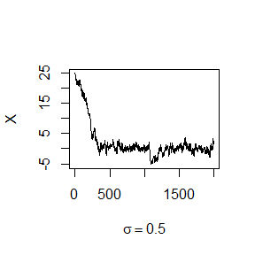

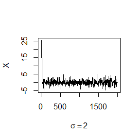

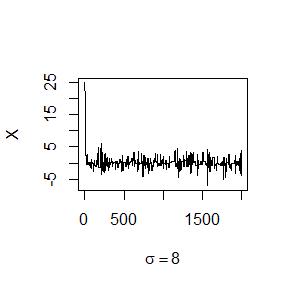

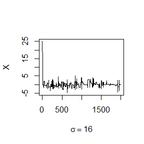

```r
rw <- cbind(rw1$x, rw2$x, rw3$x, rw4$x)
for (j in 1:4) {
plot((rw)[,j],
     type="l",
     xlab=bquote(sigma == .(round(sigma[j],3))),
     ylab="X",
     ylim=range(rw[,j]))
}
```

*step3*

Use the Gelman-Rubin method to monitor convergence of the chain, and run the chain until it converges approximately to the target distribution according to $\hat{R}<1.2$ Use the length of 20k, 2k, 2k and 1.5k for the total length of each chain and 5k, 500, 200 and 100 to burn respectively. Repeat this process with each variance used previously.

```r
k <- 4
n <- c(20000, 2000, 2000, 1500)
b <- c(5000, 500, 200, 100)
for (i in 1:k) {
    Gelman(n[i], b[i], sigma[i], k)
}
```

```
## [1] 1.185172
```

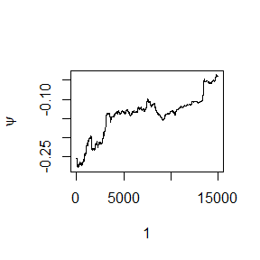

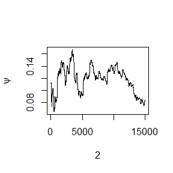

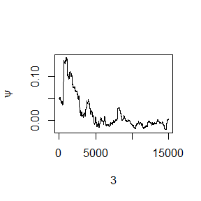

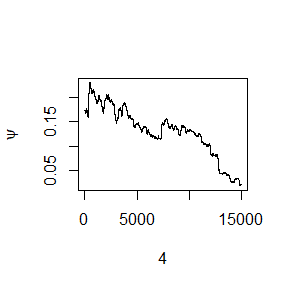

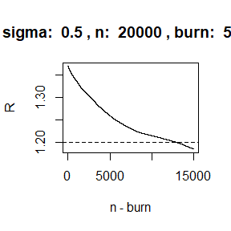

```
## [1] 1.153269
```

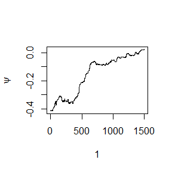

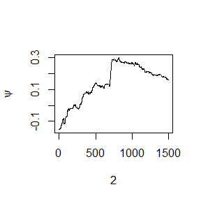

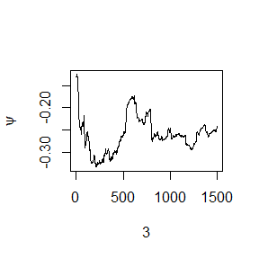

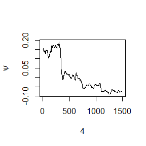

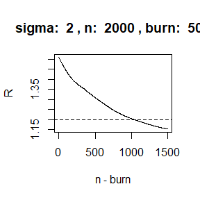

```
## [1] 1.142385
```

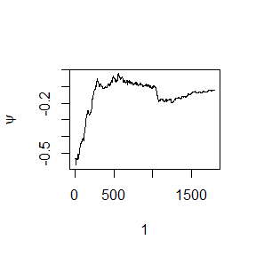

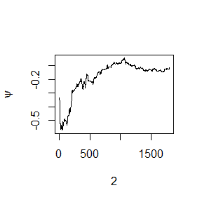

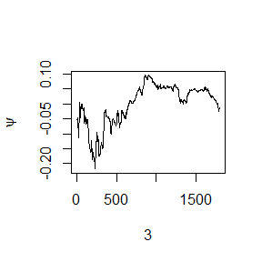

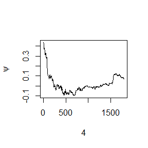

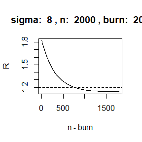

```
## [1] 1.060617
```

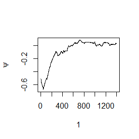

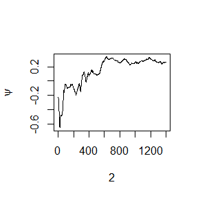

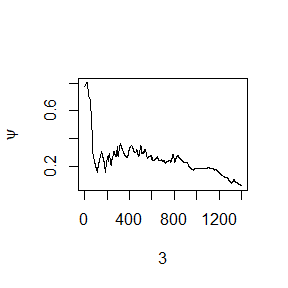

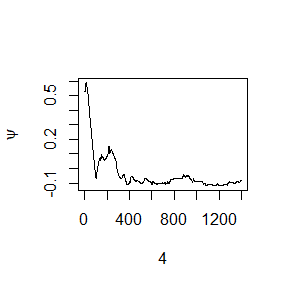

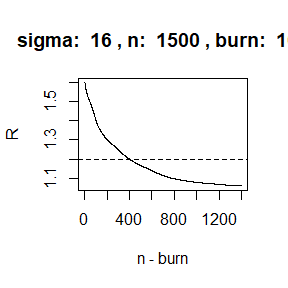

```r
rm(list=ls())
gc()
```

```
##           used (Mb) gc trigger (Mb) max used  (Mb)
## Ncells  778864 41.6    1366928 73.1  1366928  73.1
## Vcells 1745883 13.4    9197056 70.2 45121357 344.3
```

## Question 2:

9.7 Implement a Gibbs sampler to generate a bivariate normal chain $(X_{t}, Y_{t})$ with zero means, unit standard deviations, and correlation 0.9. Plot the generated sample after discarding a suitable burn-in sample. Fit a simple linear regression model Y = β0 + β1X to the sample and check the residuals of the model for normality and constant variance.

```
Use the Gelman-Rubin method to monitor convergence of the chain, and run the chain until it converges approximately to the target distribution according to $\hat{R}<1.2$
```